# Predicting Hospital Readmits for Diabetics

## Introduction

Diabetes is a metabolic disorder that results in high blood sugar. It occurs when the pancreas fails to produce enough insulin or when body cells do not respond properly to the insulin produced. It currently affects over 400 million people worldwide and is a growing problem here in the United States. My inspiration for this project stems from how this disease has affected my family - I have witnessed the complications associated with it. Thus, I am interested in learning more about the disease and its effects in a larger context.

This dataset includes hospital records from 130 location between 1999 and 2008. Even though the disease is even more prominent now, this set includes features, such as lab tests, gender, age, race, etc., that are still very relevent in learning more about the disease. The data comes from the UCI Repository. I hope to apply some classification models to make predictions about patient readmits.

```r
library(ggplot2)
library(dummies)
library(dplyr)
#Reading the Data
data <- read.csv("diabetic_data.csv")
```

```r
#Cleaning the Data
data$weight <- NULL
data$payer_code <- NULL
data$encounter_id <- NULL
data$patient_nbr <- NULL
data$admission_source_id <- NULL
data$change <- NULL
data$examide <- NULL
data$citoglipton <- NULL
data$medical_specialty <- NULL
data$admission_type_id <- as.factor(data$admission_type_id)
data$discharge_disposition_id<- as.factor(data$discharge_disposition_id)
data$diag_1 <- as.integer(data$diag_1)
data$diag_2 <- as.integer(data$diag_2)
data$diag_3 <- as.integer(data$diag_3)
data <- data[!(data$number_diagnoses < 3),]
```

### Do people make an effort to improve their health after receiving poor diagnosis results?

Figure 1 shows the relationship between the first and second diagnosis by race and gender for each record. I originally hypothesized that poor results for the first would lead to individuals taking active measure on their health to improve for the second measurement. However, this does not seem to be the case. It appears that the results are pretty arbritrary from first to second diagnosis with some measurements increasing, some decreasing, and some staying the same.

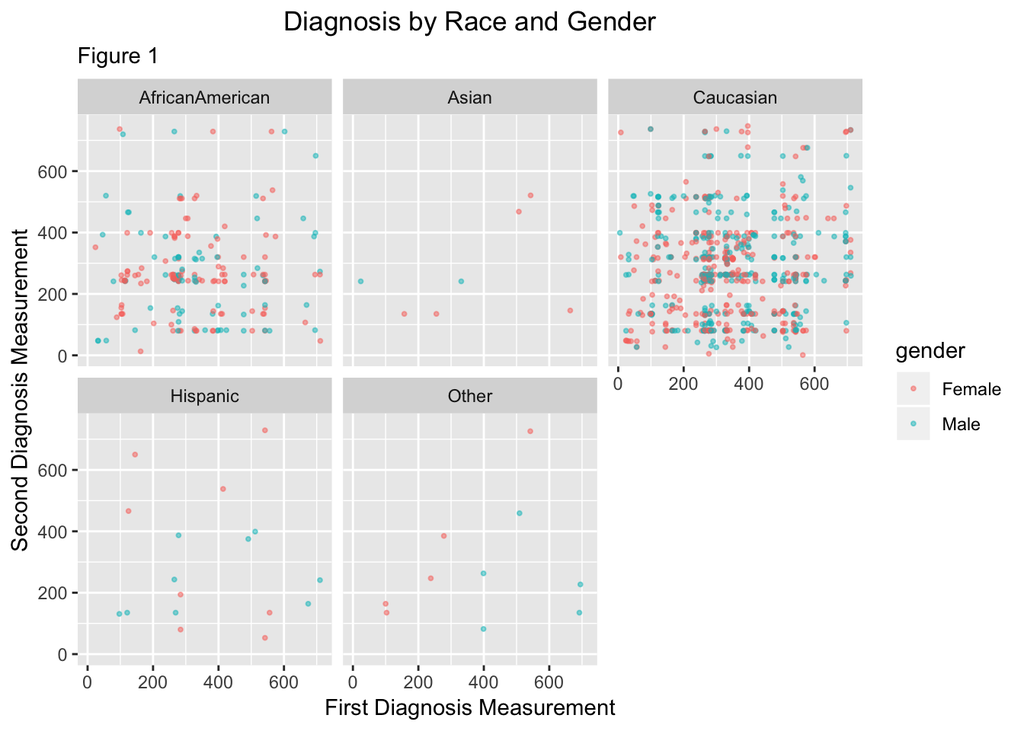

```r
data = data[sample(nrow(data)), ]
sample_data1 <- data[1:1000,] #taking 1% of the data
sample_data1 <- sample_data1[!(sample_data1$race == "?"),]
baseplot1 <- ggplot(data = sample_data1, aes(x = diag_1, y = diag_2, color = gender))
baseplot1 + geom_point(size=0.7, alpha=0.5) + facet_wrap(~ race) + ggtitle("Diagnosis by Race and Gender") + xlab("First Diagnosis Measurement") + ylab("Second Diagnosis Measurement") +
  theme(plot.title = element_text(hjust = 0.5)) + labs(subtitle = "Figure 1") #+ theme(panel.grid.major = element_blank(), panel.grid.minor = element_blank())
```

## Is there any difference in the number of lab procedures needed for each age groups?

Overall, there does not appear to be a significant difference in the number of lab procedures needed for each age group. Fourty-three lab procedures are customary regardless of age, which makes sense as there are probably set-in-stone procedures that must be administered on every patient when admitted to the hospital with diabetes.

```r
lab_age <- aggregate(data$num_lab_procedures, list(data$age), mean, na.rm = TRUE)
names(lab_age) = c("Age Group", "Avg Number of Lab Procedures")
lab_age
```

```
##    Age Group Avg Number of Lab Procedures
## 1     [0-10)                     43.64615
## 2    [10-20)                     44.63559
## 3    [20-30)                     43.09235
## 4    [30-40)                     43.16588
## 5    [40-50)                     42.93071
## 6    [50-60)                     42.69518
## 7    [60-70)                     42.65325
## 8    [70-80)                     43.19824
## 9    [80-90)                     44.11508
## 10  [90-100)                     44.70538
```

## How much time can we expect to keep patients in the hospital?

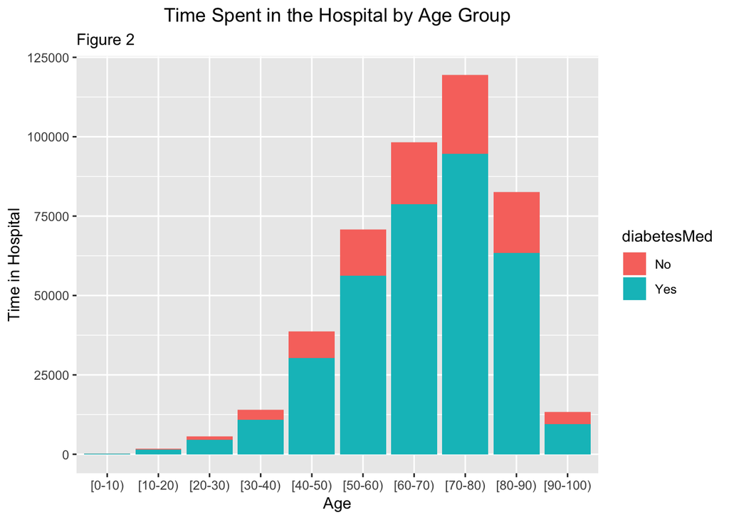

```r
ggplot(data, aes(fill = diabetesMed, y = time_in_hospital, x = age)) + geom_bar(stat = "identity") + ggtitle("Time Spent in the Hospital by Age Group") + xlab("Age") + ylab("Time in Hospital") + theme(plot.title = element_text(hjust = 0.5)) + labs(subtitle = "Figure 2")
```

## Can we create a model to predict hospital time needed by patients?

Based on our linear model below, we can see that some of the most significant variables include the number of incoming patients, emergencies, and diagnoses. This makes sense because if a hospital were to be busy on any given day, they would probably spend less time with each patient. Additionally, insulin and glipizide levels appear to be very significant. It is interesting that features associated with the hospital condition appear more significant than most of the conditions of the patient. This could mean that insulin and glipizide levels are the two most important things to look at when administering tests on a diabetic patient to determine whether or not they are in need of intensive care.

It is important to note that our model appears to have a very low p-value (less than 0.05), which indicates that there is some relationship between the features we identified and the time needed by patients. However, our adjusted R-squared value is very low (0.073), which indicates that this model is not the best fit.

```r
#Linear Regression

predict_time_needed <- lm(data = data, data$time_in_hospital ~ number_inpatient + number_emergency + number_diagnoses + max_glu_serum + race + diabetesMed + glipizide + insulin + gender + age)

summary(predict_time_needed)
```

```
##
## Call:
## lm(formula = data$time_in_hospital ~ number_inpatient + number_emergency +
##     number_diagnoses + max_glu_serum + race + diabetesMed + glipizide +
##     insulin + gender + age, data = data)
##
## Residuals:
##     Min      1Q  Median      3Q     Max
## -6.6509 -2.0787 -0.6917  1.4248 11.9128
##
## Coefficients:
##                        Estimate Std. Error t value Pr(>|t|)
## (Intercept)            3.868247   0.392731   9.850  < 2e-16 ***
## number_inpatient       0.130844   0.007543  17.347  < 2e-16 ***
## number_emergency      -0.126908   0.010182 -12.464  < 2e-16 ***
## number_diagnoses       0.299157   0.005167  57.899  < 2e-16 ***
## max_glu_serum>300      0.580374   0.111191   5.220 1.80e-07 ***
## max_glu_serumNone     -0.399524   0.075940  -5.261 1.44e-07 ***
## max_glu_serumNorm     -0.588812   0.094383  -6.239 4.43e-10 ***
## raceAfricanAmerican    0.126066   0.064762   1.947 0.051584 .
## raceAsian             -0.428485   0.130207  -3.291 0.000999 ***
## raceCaucasian         -0.211294   0.062144  -3.400 0.000674 ***
## raceHispanic          -0.267512   0.089058  -3.004 0.002667 **
## raceOther             -0.209858   0.096613  -2.172 0.029848 *
## diabetesMedYes         0.056801   0.027778   2.045 0.040874 *
## glipizideNo           -1.398395   0.122613 -11.405  < 2e-16 ***
## glipizideSteady       -1.380122   0.124948 -11.046  < 2e-16 ***
## glipizideUp            0.298399   0.160237   1.862 0.062573 .
## insulinNo             -0.686393   0.033084 -20.747  < 2e-16 ***
## insulinSteady         -0.491235   0.031205 -15.742  < 2e-16 ***
## insulinUp              0.315502   0.037849   8.336  < 2e-16 ***
## genderMale            -0.138693   0.018394  -7.540 4.73e-14 ***
## genderUnknown/Invalid -0.525092   1.662457  -0.316 0.752115
## age[10-20)             0.377217   0.380863   0.990 0.321967
## age[20-30)            -0.041470   0.364887  -0.114 0.909515
## age[30-40)             0.206418   0.360505   0.573 0.566929
## age[40-50)             0.329671   0.358604   0.919 0.357932
## age[50-60)             0.385362   0.358096   1.076 0.281866
## age[60-70)             0.579268   0.357983   1.618 0.105635
## age[70-80)             0.768684   0.357956   2.147 0.031762 *
## age[80-90)             0.915162   0.358242   2.555 0.010633 *
## age[90-100)            0.863436   0.361704   2.387 0.016982 *
## ---
## Signif. codes:  0 '***' 0.001 '**' 0.01 '*' 0.05 '.' 0.1 ' ' 1
##
## Residual standard error: 2.878 on 100494 degrees of freedom
## Multiple R-squared:  0.07383,    Adjusted R-squared:  0.07356
## F-statistic: 276.2 on 29 and 100494 DF,  p-value: < 2.2e-16
```

## Do more tests lead to more medications?

There is a somewhat upward trend males - as the number of lab procedures increase, the number of medications they are placed on increases regardless of whether their insulin levels are high, low, or steady. There also appears to be more male outliers with high insulin in comparison to women. Overall, results for women follow a similar trend, but with smaller variance in comparison to men.

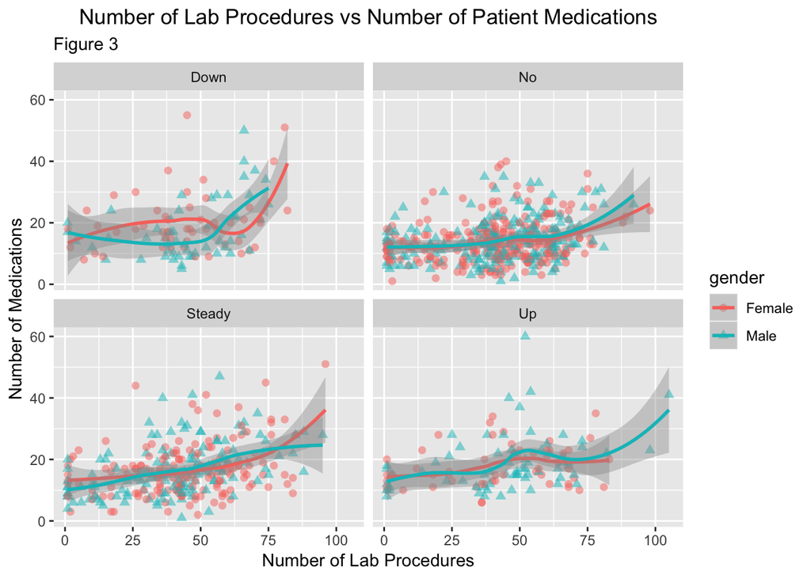

```r
ggplot(sample_data1, aes(x = num_lab_procedures, y = num_medications, color = gender, shape = gender)) + facet_wrap(~ insulin) + geom_point(size=2, alpha= 0.5) + geom_smooth() + ggtitle("Number of Lab Procedures vs Number of Patient Medications") + xlab("Number of Lab Procedures") + ylab("Number of Medications") + theme(plot.title = element_text(hjust = 0.5)) + labs(subtitle = "Figure 3")
```

## Predicting diabetic readmittance to the hospital with K-Nearest Neighbors

We use KNN as a simple approach in trying to predict hospital readmittance. This algorithm identifies k records in the training set that are closest in features to our observation. It does this by calculating the Euclidean distance in multi-dimensional space between our observation and its neighbors.

```r
#Randomize, Dummy, Standardize, Subset(10,000 entries), Split Train and Test

randomized_data = data[sample(nrow(data)), ]

data_dummies <- dummy.data.frame(randomized_data[1:40], drop = FALSE)

standardized_data <- as.data.frame(scale(data_dummies[1:143]))   #z-score standardization

standardized_data["readmitted"] <- randomized_data$readmitted

subset_data <- standardized_data[1:10000,] #replace with full data after training

df_train <- subset_data %>% sample_frac(.75)
df_test <- subset_data %>% sample_frac(.25)
df_trainlabels <- as.factor(df_train$readmitted)
df_testlabels <- as.factor(df_test$readmitted)

df_test$readmitted <- NULL
```

```r
#KNN

library(class)
library(e1071)
library(gmodels)
library(caret)
df_train$readmitted <- NULL

knn_predictions <- knn(train = df_train, test = df_test, df_trainlabels , k = 100)

CrossTable(x = df_testlabels, y = knn_predictions, prop.chisq = FALSE)
```

```
##
##
##    Cell Contents
## |-------------------------|
## |                       N |
## |           N / Row Total |
## |           N / Col Total |
## |         N / Table Total |
## |-------------------------|
##
##
## Total Observations in Table:  2500
##
##
##               | knn_predictions
## df_testlabels |       >30 |        NO | Row Total |
## --------------|-----------|-----------|-----------|
##           <30 |        37 |       236 |       273 |
##               |     0.136 |     0.864 |     0.109 |
##               |     0.182 |     0.103 |           |
##               |     0.015 |     0.094 |           |
## --------------|-----------|-----------|-----------|
##           >30 |        94 |       778 |       872 |
##               |     0.108 |     0.892 |     0.349 |
##               |     0.463 |     0.339 |           |
##               |     0.038 |     0.311 |           |
## --------------|-----------|-----------|-----------|
##            NO |        72 |      1283 |      1355 |
##               |     0.053 |     0.947 |     0.542 |
##               |     0.355 |     0.559 |           |
##               |     0.029 |     0.513 |           |
## --------------|-----------|-----------|-----------|
##  Column Total |       203 |      2297 |      2500 |
##               |     0.081 |     0.919 |           |
## --------------|-----------|-----------|-----------|
##
##
```

```r
confusionMatrix(knn_predictions, df_testlabels)
```

```
## Confusion Matrix and Statistics
##
##           Reference
## Prediction  <30  >30   NO
##        <30    0    0    0
##        >30   37   94   72
##        NO   236  778 1283
##
## Overall Statistics
##
##                Accuracy : 0.5508
##                  95% CI : (0.5311, 0.5704)
##     No Information Rate : 0.542
##     P-Value [Acc > NIR] : 0.1941
##
##                   Kappa : 0.0517
##  Mcnemar's Test P-Value : <2e-16
##
## Statistics by Class:
##
##                      Class: <30 Class: >30 Class: NO
## Sensitivity              0.0000     0.1078    0.9469
## Specificity              1.0000     0.9330    0.1144
## Pos Pred Value              NaN     0.4631    0.5586
## Neg Pred Value           0.8908     0.6613    0.6453
## Prevalence               0.1092     0.3488    0.5420
## Detection Rate           0.0000     0.0376    0.5132
## Detection Prevalence     0.0000     0.0812    0.9188
## Balanced Accuracy        0.5000     0.5204    0.5306
```

## Predicting diabetic readmittance to the hospital with Support Vector Machines

Support Vector Machines (SVM) is another machine learning algorithm that also uses multidimensional surfaces to discover the relationship between features and outcomes. They combine aspects from instance driven KNN models and linear regression, which allows them to model more complex relationships. Essentially, the model attempts to draws hyper-planes between observations of similar features. Planes are drawn to the right and left of these hyper-planes to calculate the distance from the observed points in each category to the hyper-plane. The best choices will be the hyper-planes that leave the maximum margin from the data points in each class.

```r
#SVM
library(kernlab)
df_train["readmitted"] <- df_trainlabels
diabetes_classifier <-ksvm(df_train$readmitted ~ ., data = df_train, kernal = "vanilladot")
diabetes_predictions <- predict(diabetes_classifier, df_test)

table(diabetes_predictions, df_testlabels)
```

```
##                     df_testlabels
## diabetes_predictions  <30  >30   NO
##                  <30    3    0    0
##                  >30   58  198  100
##                  NO   212  674 1255
```

```r
CrossTable(x = df_testlabels, y = diabetes_predictions, prop.chisq = FALSE)
```

```
##
##
##    Cell Contents
## |-------------------------|
## |                       N |
## |           N / Row Total |
## |           N / Col Total |
## |         N / Table Total |
## |-------------------------|
##
##
## Total Observations in Table:  2500
##
##
##               | diabetes_predictions
## df_testlabels |       <30 |       >30 |        NO | Row Total |
## --------------|-----------|-----------|-----------|-----------|
##           <30 |         3 |        58 |       212 |       273 |
##               |     0.011 |     0.212 |     0.777 |     0.109 |
##               |     1.000 |     0.163 |     0.099 |           |
##               |     0.001 |     0.023 |     0.085 |           |
## --------------|-----------|-----------|-----------|-----------|
##           >30 |         0 |       198 |       674 |       872 |
##               |     0.000 |     0.227 |     0.773 |     0.349 |
##               |     0.000 |     0.556 |     0.315 |           |
##               |     0.000 |     0.079 |     0.270 |           |
## --------------|-----------|-----------|-----------|-----------|
##            NO |         0 |       100 |      1255 |      1355 |
##               |     0.000 |     0.074 |     0.926 |     0.542 |
##               |     0.000 |     0.281 |     0.586 |           |
##               |     0.000 |     0.040 |     0.502 |           |
## --------------|-----------|-----------|-----------|-----------|
##  Column Total |         3 |       356 |      2141 |      2500 |
##               |     0.001 |     0.142 |     0.856 |           |
## --------------|-----------|-----------|-----------|-----------|
##
##
```

```r
confusionMatrix(diabetes_predictions, df_testlabels)
```

```
## Confusion Matrix and Statistics
##
##           Reference
## Prediction  <30  >30   NO
##        <30    3    0    0
##        >30   58  198  100
##        NO   212  674 1255
##
## Overall Statistics
##
##                Accuracy : 0.5824
##                  95% CI : (0.5628, 0.6018)
##     No Information Rate : 0.542
##     P-Value [Acc > NIR] : 2.616e-05
##
##                   Kappa : 0.1408
##  Mcnemar's Test P-Value : < 2.2e-16
##
## Statistics by Class:
##
##                      Class: <30 Class: >30 Class: NO
## Sensitivity             0.01099     0.2271    0.9262
## Specificity             1.00000     0.9029    0.2262
## Pos Pred Value          1.00000     0.5562    0.5862
## Neg Pred Value          0.89187     0.6856    0.7214
## Prevalence              0.10920     0.3488    0.5420
## Detection Rate          0.00120     0.0792    0.5020
## Detection Prevalence    0.00120     0.1424    0.8564
## Balanced Accuracy       0.50549     0.5650    0.5762
```

## Predicting diabetic readmittance to the hospital with Decision Trees

```r
#Decision Tree
library(C50)

df_train$readmitted <- NULL
decision_model <- C5.0(df_train, df_trainlabels)
summary(decision_model)
```

```
##
## Call:
## C5.0.default(x = df_train, y = df_trainlabels)
##
##
## C5.0 [Release 2.07 GPL Edition]      Sat Aug 11 18:46:30 2018
## -------------------------------
##
## Class specified by attribute `outcome'
##
## Read 7500 cases (144 attributes) from undefined.data
##
## Decision tree:
##
## discharge_disposition_id11 > -0.1287825: NO (137)
## discharge_disposition_id11 <= -0.1287825:
## :...discharge_disposition_id14 > -0.0609452: NO (43/3)
##     discharge_disposition_id14 <= -0.0609452:
##     :...number_inpatient <= -0.506314:
##         :...number_emergency <= -0.2129911: NO (4520/1710)
##         :   number_emergency > -0.2129911:
##         :   :...number_diagnoses <= -0.8100931: NO (83/36)
##         :       number_diagnoses > -0.8100931: >30 (268/140)
##         number_inpatient > -0.506314:
##         :...discharge_disposition_id22 > -0.1420757:
##             :...insulinDown > -0.3688572: <30 (6)
##             :   insulinDown <= -0.3688572:
##             :   :...glipizideNo <= -2.641116: >30 (4/1)
##             :       glipizideNo > -2.641116:
##             :       :...diag_3 <= 0.3160655: NO (18/7)
##             :           diag_3 > 0.3160655: <30 (12/4)
##             discharge_disposition_id22 <= -0.1420757:
##             :...number_inpatient > 1.078611: >30 (517/251)
##                 number_inpatient <= 1.078611:
##                 :...discharge_disposition_id2 > -0.1467775:
##                     :...insulinNo > -0.9361166: >30 (21/9)
##                     :   insulinNo <= -0.9361166:
##                     :   :...admission_type_id2 > -0.4714007: NO (4)
##                     :       admission_type_id2 <= -0.4714007:
##                     :       :...age[60-70) <= -0.5347403: <30 (20/9)
```

[output cut: 64 more lines]

```
##    6.15% insulinNo
##    3.59% glyburideNo
##    3.24% num_procedures
##    2.44% A1CresultNone
##    2.24% insulinUp
##    1.45% genderFemale
##    0.77% insulinSteady
##    0.53% insulinDown
##    0.45% glipizideNo
##    0.40% diag_3
##    0.31% age[60-70)
##    0.28% age[40-50)
##
##
## Time: 0.5 secs
```

```r
#plot(decision_model)
decision_prediction <- predict(decision_model, df_test)

CrossTable(df_testlabels, decision_prediction, prop.chisq = FALSE, prop.c = FALSE, prop.r = FALSE, dnn = c('actual leaving', 'predicted leaving'))
```

```
##
##
##    Cell Contents
## |-------------------------|
## |                       N |
## |         N / Table Total |
## |-------------------------|
##
##
## Total Observations in Table:  2500
##
##
##                | predicted leaving
## actual leaving |       <30 |       >30 |        NO | Row Total |
## ---------------|-----------|-----------|-----------|-----------|
##            <30 |         9 |       103 |       161 |       273 |
##                |     0.004 |     0.041 |     0.064 |           |
## ---------------|-----------|-----------|-----------|-----------|
##            >30 |         1 |       316 |       555 |       872 |
##                |     0.000 |     0.126 |     0.222 |           |
## ---------------|-----------|-----------|-----------|-----------|
##             NO |         3 |       250 |      1102 |      1355 |
##                |     0.001 |     0.100 |     0.441 |           |
## ---------------|-----------|-----------|-----------|-----------|
##   Column Total |        13 |       669 |      1818 |      2500 |
## ---------------|-----------|-----------|-----------|-----------|
##
##
```

```r
confusionMatrix(decision_prediction, df_testlabels)
```

```
## Confusion Matrix and Statistics
##
##           Reference
## Prediction  <30  >30   NO
##        <30    9    1    3
##        >30  103  316  250
##        NO   161  555 1102
##
## Overall Statistics
##
##                Accuracy : 0.5708
##                  95% CI : (0.5511, 0.5903)
##     No Information Rate : 0.542
##     P-Value [Acc > NIR] : 0.002021
##
##                   Kappa : 0.1616
##  Mcnemar's Test P-Value : < 2.2e-16
##
## Statistics by Class:
##
##                      Class: <30 Class: >30 Class: NO
## Sensitivity             0.03297     0.3624    0.8133
## Specificity             0.99820     0.7832    0.3747
## Pos Pred Value          0.69231     0.4723    0.6062
## Neg Pred Value          0.89385     0.6963    0.6290
## Prevalence              0.10920     0.3488    0.5420
## Detection Rate          0.00360     0.1264    0.4408
## Detection Prevalence    0.00520     0.2676    0.7272
## Balanced Accuracy       0.51559     0.5728    0.5940
```

```r
#AdaBoosted Decision Tree

decision_boost10 <- C5.0(df_train, df_trainlabels, trials = 10)
decision_boost10
```

```
##
## Call:
## C5.0.default(x = df_train, y = df_trainlabels, trials = 10)
##
## Classification Tree
## Number of samples: 7500
## Number of predictors: 143
##
## Number of boosting iterations: 10 requested;  4 used due to early stopping
## Average tree size: 14.5
##
## Non-standard options: attempt to group attributes
```

```r
decision_boost_pred10 <- predict(decision_boost10, df_test)
CrossTable(df_testlabels, decision_boost_pred10, prop.chisq = FALSE, prop.c = FALSE, prop.r = FALSE, dnn = c('actual leaving', 'predicted leaving'))
```

```
##
##
##    Cell Contents
## |-------------------------|
## |                       N |
## |         N / Table Total |
## |-------------------------|
##
##
## Total Observations in Table:  2500
##
##
##                | predicted leaving
## actual leaving |       >30 |        NO | Row Total |
## ---------------|-----------|-----------|-----------|
##            <30 |        75 |       198 |       273 |
##                |     0.030 |     0.079 |           |
## ---------------|-----------|-----------|-----------|
##            >30 |       197 |       675 |       872 |
##                |     0.079 |     0.270 |           |
## ---------------|-----------|-----------|-----------|
##             NO |       126 |      1229 |      1355 |
##                |     0.050 |     0.492 |           |
## ---------------|-----------|-----------|-----------|
##   Column Total |       398 |      2102 |      2500 |
## ---------------|-----------|-----------|-----------|
##
##
```

```r
confusionMatrix(decision_boost_pred10, df_testlabels)
```

```
## Confusion Matrix and Statistics
##
##           Reference
## Prediction  <30  >30   NO
##        <30    0    0    0
##        >30   75  197  126
##        NO   198  675 1229
##
## Overall Statistics
##
##                Accuracy : 0.5704
##                  95% CI : (0.5507, 0.5899)
##     No Information Rate : 0.542
##     P-Value [Acc > NIR] : 0.002294
##
##                   Kappa : 0.121
##  Mcnemar's Test P-Value : < 2.2e-16
##
## Statistics by Class:
##
##                      Class: <30 Class: >30 Class: NO
## Sensitivity              0.0000     0.2259    0.9070
## Specificity              1.0000     0.8765    0.2376
## Pos Pred Value              NaN     0.4950    0.5847
## Neg Pred Value           0.8908     0.6789    0.6834
## Prevalence               0.1092     0.3488    0.5420
## Detection Rate           0.0000     0.0788    0.4916
## Detection Prevalence     0.0000     0.1592    0.8408
## Balanced Accuracy        0.5000     0.5512    0.5723
```